# Ford GoBike System

## by Amira Hagag

## Investigation Overview

> Today we will introduce abike share project across ("San Fransisco, New York and Boston"). The main purpose for this invistigation to show the impact of this project on the members that participated and also on the enviroment.

## Dataset Overview

> In this project we collect data from bike sharing system used across different cities which are ("San Fransisco, New York and Boston ("Boston / Brookline / Cambridge / Somerville, MA" we abreviated here as "Boston" to be easily investigate), This data set includes information about individual rides made in a bike-sharing system covering the previously mentioned cities.

> The dataset after cleaning contains 1198372 trips with 16 features which are (duration_min, start_station_name, end_station_name, bike_id, user_type, member_age, member_gender, city, start_date, end_date, start_day_of_Week, end_day_of_Week, start_day_Week_type, end_day_Week_type, start_hour and end_hour)

## Distribution for trip duration

> Most of the trips has low duration (less than 100 minute), for the trips with duration less than 100 minute, the distribuation is almost symmetric with peak value at 10 minute, so we can say that the no of trips increase with duration increased till we reach 10 minute duration, the no of trips starts to decrease with the duration increased.

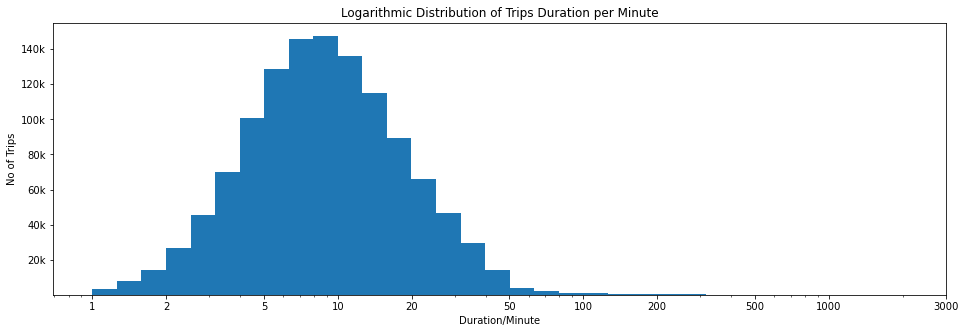

```python
log_binsize = 0.1
bins = 10 ** np.arange(0, np.log10(df_clean['duration_min'].max())+log_binsize, log_binsize)
plt.figure(figsize=[16, 5])
plt.hist(data = df_clean, x = 'duration_min', bins = bins)
plt.xscale('log')
x_ticks = [1, 2, 5, 10, 20, 50, 1e2, 2e2, 5e2, 1e3, 3e3]
x_ticks_labels = [1, 2, 5, 10, 20, 50, 100, 200, 500, 1000, 3000]
y_ticks = [20000, 40000, 60000, 80000, 100000, 120000, 140000]
y_ticks_labels = ['20k', '40k', '60k', '80k', '100k', '120k', '140k']

plt.title('Logarithmic Distribution of Trips Duration per Minute')
plt.ylabel('No of Trips')
plt.xlabel('Duration/Minute')
plt.xticks( x_ticks, x_ticks_labels)
plt.yticks( y_ticks, y_ticks_labels)

plt.show()
```

## Distribution for Members Age

> Most of the ages between 20 and 80 years old, With peak value at age 30 with number of trips reach around 240k trip, the age of the contributers start from around 15 years old with very low number of trips between 15 to 20 and at 20 the number of trips jumps to above 50k trip then there is a big jump also between 25 and 30 and we reach peak number of trips at 30-35 then the no of trips starts to decrease with the age increaed and there is a jump between age 50-55.

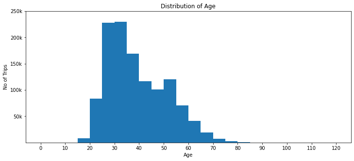

```python
# let's now show how age distrubted
binsize = 5
bins = np.arange(0, df_clean['member_age'].max()+binsize, binsize)
x_ticks = [0, 10, 20, 30, 40, 50, 60, 70, 80, 90, 100, 110, 120]
y_ticks = [50000, 100000, 150000, 200000, 250000]
y_ticks_labels= ['50k', '100k', '150k', '200k', '250k']

plt.figure(figsize=[12, 5])
plt.hist(data = df_clean, x = 'member_age', bins = bins)

plt.title('Distribution of Age')
plt.ylabel('No of Trips')
plt.xlabel('Age')
plt.xticks(x_ticks)
plt.yticks(y_ticks, y_ticks_labels)
plt.show()
```

## Distribution of trips over the Cities:

> The number of trips in New York City is very large compared to the number of trips in San Fransisco or Boston, New York City is the Largest No of trips with (78.7 %) from all trips then San Fransisco City with (14.59%) and the lowest number for Boston City with (6.71%)

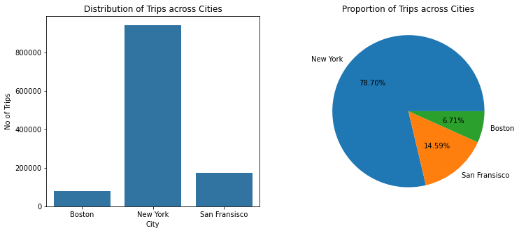

```python
# let's now show no of trips in each city

plt.figure(figsize=[12, 5])

plt.subplot(1, 2, 1)
sb.countplot(data = df_clean, x = 'city', color = base_color)

plt.title('Distribution of Trips across Cities')
plt.ylabel('No of Trips')
plt.xlabel('City')


plt.subplot(1, 2, 2)
cities_values = df_clean['city'].value_counts()
plt.pie(cities_values, labels = cities_values.index, autopct='%1.2f%%')
plt.title('Proportion of Trips across Cities')

plt.show()
```

## Distribution of Trips across User Types

> Most of the users are subscribers as the subscribers number of trips exceeds 1 million with (94.2 %) from all trips, while the customers no of trips not reach 100k with (5.8%) from all trips

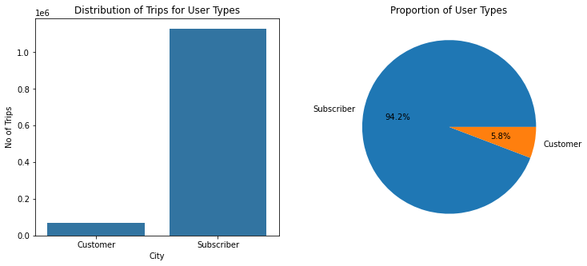

```python
# let's now show no of trips in each user types

plt.figure(figsize=[12, 5])

plt.subplot(1, 2, 1)
sb.countplot(data = df_clean, x = 'user_type', color = base_color)

plt.title('Distribution of Trips for User Types')
plt.ylabel('No of Trips')
plt.xlabel('City')


plt.subplot(1, 2, 2)
users_values = df_clean['user_type'].value_counts()
plt.pie(users_values, labels = users_values.index, autopct='%1.1f%%')
plt.title('Proportion of User Types')

plt.show()
```

## Distribution of Trips across User Gender

> The strange part here is the percentage of males around 3.5 times the percentage of females

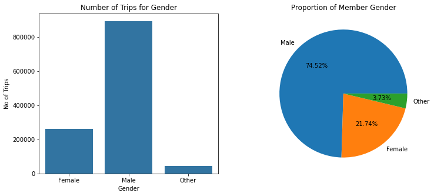

```python
# let's now show no of trips in each gender

plt.figure(figsize=[12, 5])

plt.subplot(1, 2, 1)
sb.countplot(data = df_clean, x = 'member_gender', color = base_color)

plt.title('Number of Trips for Gender')
plt.ylabel('No of Trips')
plt.xlabel('Gender')


plt.subplot(1, 2, 2)
gender_values = df_clean['member_gender'].value_counts()
plt.pie(gender_values, labels = gender_values.index, autopct='%1.2f%%')
plt.title('Proportion of Member Gender')

plt.show()
```

## Distribution of Trips over Day Hour

> The peak values for the start hour and end hour are the same and its around 8-9 AM and 5-6 PM and this is normal because this is the time people go to work and get back to home.

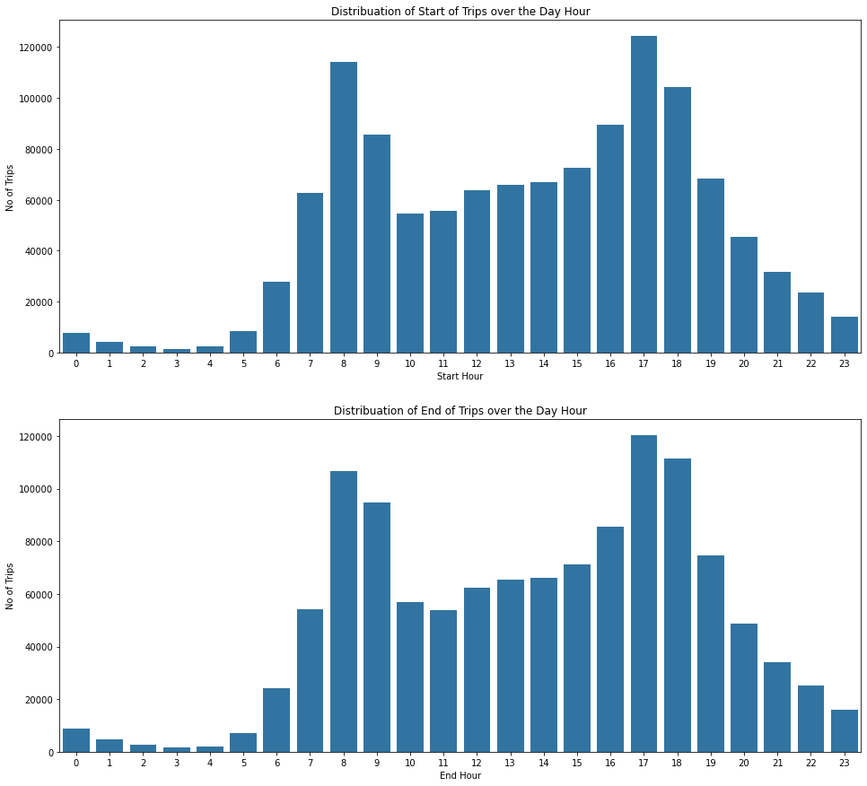

```python
# let's now show The Distribution of no of trips over the Day Hour
plt.figure(figsize=[16, 15])
plt.subplot(2, 1, 1)

sb.countplot(data = df_clean, x = 'start_hour', color = base_color)
plt.title('Distribuation of Start of Trips over the Day Hour')
plt.ylabel('No of Trips')
plt.xlabel('Start Hour')


plt.subplot(2, 1, 2)
sb.countplot(data = df_clean, x = 'end_hour', color = base_color)
plt.title('Distribuation of End of Trips over the Day Hour')
plt.xlabel('End Hour')
plt.ylabel('No of Trips')

plt.show()
```

## Distribution of trips over the week days

> The Distribution of trips over the week days is normal the different between days not too much except for week end days (saturday and sunday) is less than the work days.

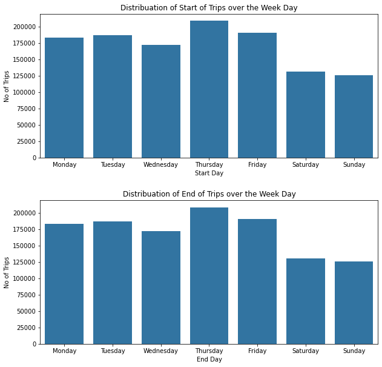

```python
# let's now show The Distribution of no of trips over the Day of the week

plt.figure(figsize=[10, 10])
plt.subplot(2, 1, 1)
plt.subplots_adjust(hspace=0.3)
days_order=['Monday', 'Tuesday', 'Wednesday', 'Thursday','Friday','Saturday','Sunday']

sb.countplot(data = df_clean, order=days_order ,x = 'start_day_of_Week', color = base_color)
plt.title('Distribuation of Start of Trips over the Week Day')
plt.ylabel('No of Trips')
plt.xlabel('Start Day')

plt.subplot(2, 1, 2)
sb.countplot(data = df_clean, order=days_order , x = 'end_day_of_Week', color = base_color)
plt.title('Distribuation of End of Trips over the Week Day')
plt.xlabel('End Day')
plt.ylabel('No of Trips')

plt.show()
```

## Distribution of trips across (User Type vs Gender vs City)

> The number of trips for the user type not affected by the other values like gender and city , it showed same distribution which is the value for subscriber is so high with respect to the value for the customer with any city or gender.

> The gender also not affected by othe values, it also showed large value for males with respect to females for any user type or city.

> The value for city also the same like the other two categorical values not affected by the other feature and shwed large number for New York with respect to San Fransisco and Boston with any user type or gender.

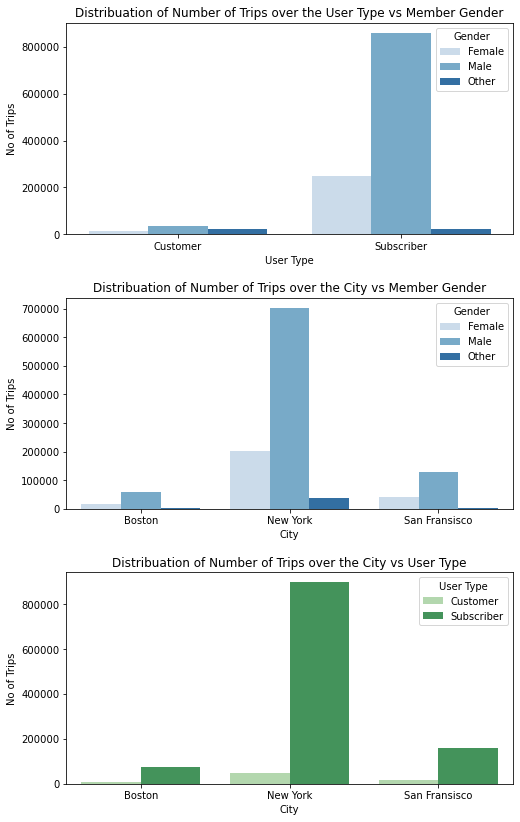

```python
# let's display the important categorical feature together
plt.figure(figsize = [8, 14])
plt.subplots_adjust(hspace=0.3)
# subplot 1: display user type and member gender
plt.subplot(3, 1, 1)
sb.countplot(data = df_clean, x = 'user_type', hue = 'member_gender', palette = 'Blues')
plt.title('Distribuation of Number of Trips over the User Type vs Member Gender')
plt.legend(title="Gender")
plt.xlabel("User Type")
plt.ylabel('No of Trips')

# subplot 2: display city and member gender
ax = plt.subplot(3, 1, 2)
sb.countplot(data = df_clean, x = 'city', hue = 'member_gender', palette = 'Blues')
plt.title('Distribuation of Number of Trips over the City vs Member Gender')
plt.legend(title="Gender")
plt.xlabel("City")
plt.ylabel('No of Trips')

# subplot 3: display city and user type
ax = plt.subplot(3, 1, 3)
sb.countplot(data = df_clean, x = 'city', hue = 'user_type', palette = 'Greens')
plt.title('Distribuation of Number of Trips over the City vs User Type')
plt.legend(title="User Type")
plt.xlabel("City")
plt.ylabel('No of Trips')

plt.show()
```

## Distribution of Trips across (Day Hour and Day Type)

> This shows that the peak hour for the week end different from the peak hour in the week days, for the week days the peak hours 8-9 AM and 5-6 PM and for the week end days from 1 PM and 3PM.

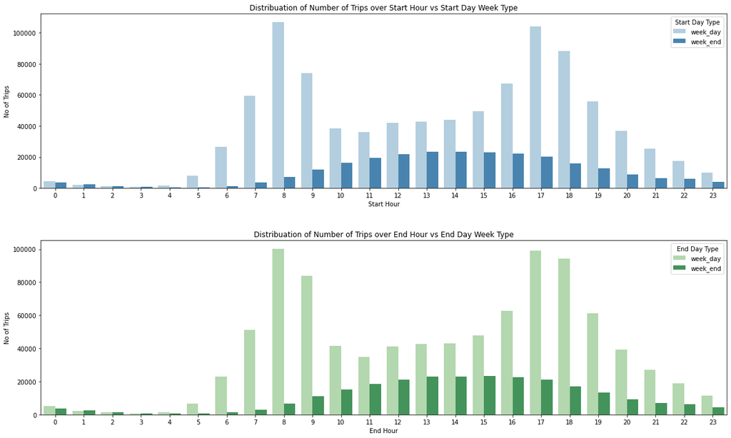

```python
# let's display relation between (start_hour, start_day_Week_type) (end_hour, end_day_week_type)
plt.figure(figsize = [20, 12])
plt.subplots_adjust(hspace=0.3)
# subplot 1: display start_hour, start_day_Week_type
plt.subplot(2, 1, 1)
sb.countplot(data = df_clean, x = 'start_hour', hue = 'start_day_Week_type', palette = 'Blues')
plt.title('Distribuation of Number of Trips over Start Hour vs Start Day Week Type')
plt.legend(title="Start Day Type")
plt.xlabel("Start Hour")
plt.ylabel('No of Trips')

# subplot 2: display end_hour, end_day_week_type
plt.subplot(2, 1, 2)
sb.countplot(data = df_clean, x = 'end_hour', hue = 'end_day_Week_type', palette = 'Greens')
plt.title('Distribuation of Number of Trips over End Hour vs End Day Week Type')
plt.legend(title="End Day Type")
plt.xlabel("End Hour")
plt.ylabel('No of Trips')

plt.show()
```

## Trip Duration vs The Member Age

> The Distribution of age with respect to duration shows that the duration increase with age increase till age 30 which is the peak then the duration decrease as the age increase but as we found previous there is jump in graph at age 50.

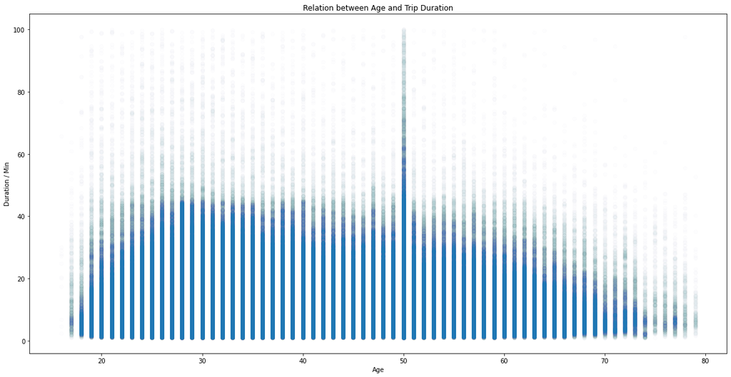

```python
# let's get closer look in the relation between and duration and age feature
# First Limit the duration to get closer look
df_clean_time_age_limit = df_clean.query('duration_min < 100 and member_age < 80')

plt.figure(figsize = [20, 10])
plt.scatter(data = df_clean_time_age_limit, x = 'member_age', y = 'duration_min', alpha = 0.007)
plt.title('Relation between Age and Trip Duration')
plt.xlabel('Age')
plt.ylabel('Duration / Min')
plt.show()
```

## Distribution of Trips across (Day Hour and User Type)

> The start and end hour affected by the type of user, it provides that the peak hour for subscriber different from the peak hour in the customer, for the subscriber the peak hours 8-9 AM and 5-6 PM and for the customer from 3 PM and 5PM.

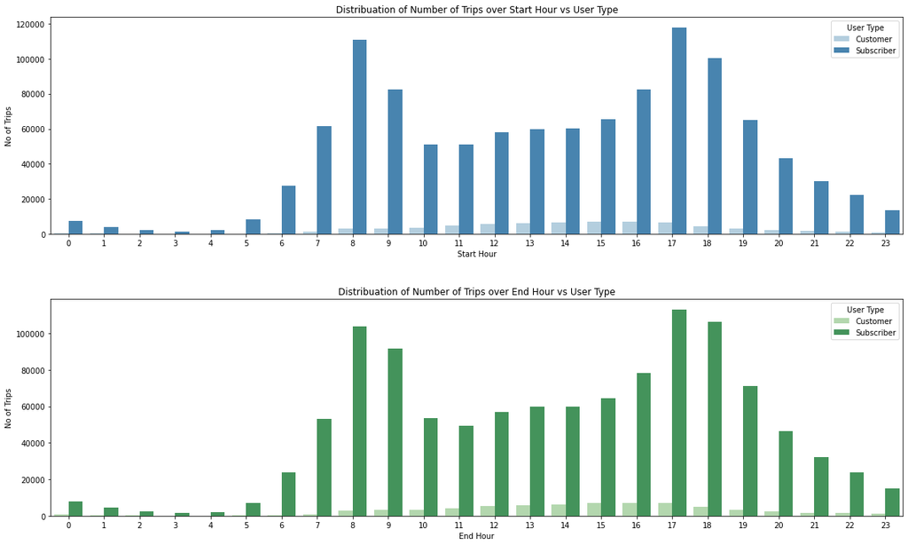

```python
# let's display (start_hour, user_type) (end_hour, user_type)
plt.figure(figsize = [20, 12])
plt.subplots_adjust(hspace=0.3)

# subplot 1: display start_hour, user_type
plt.subplot(2, 1, 1)
sb.countplot(data = df_clean, x = 'start_hour', hue = 'user_type', palette = 'Blues')
plt.title('Distribuation of Number of Trips over Start Hour vs User Type')
plt.legend(title="User Type")
plt.xlabel("Start Hour")
plt.ylabel('No of Trips')


# subplot 2: display end_hour, user_type
plt.subplot(2, 1, 2)
sb.countplot(data = df_clean, x = 'end_hour', hue = 'user_type', palette = 'Greens')
plt.title('Distribuation of Number of Trips over End Hour vs User Type')
plt.legend(title="User Type")
plt.xlabel("End Hour")
plt.ylabel('No of Trips')


plt.show()
```

## Relation Between (Duration , Gender , User Type)

> The female customers spend more time in the trip than female subscribers and the same for males.

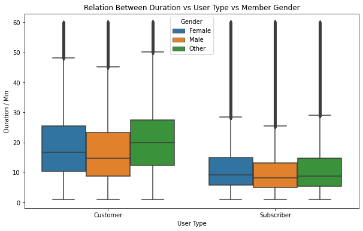

```python
# let's get the relation between duration , member_gender, user type
plt.figure(figsize=[10, 6])
sb.boxplot(data = df_clean_duration, x = 'user_type',  y = 'duration_min', hue='member_gender')
plt.legend(title="Gender")
plt.xlabel("User Type")
plt.ylabel("Duration / Min")
plt.title('Relation Between Duration vs User Type vs Member Gender')

plt.show()
```

## Relation between ( Duration, City, User Type)

> The Customers in New York spend more time than the customers in Boston than the customers in San Fransisco, but for the subscribers the duration is almost the same for all members regardless the city.

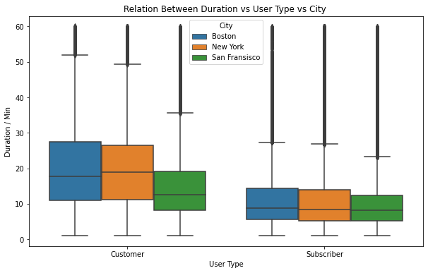

```python
# let's get the relation between duration, city, user type
plt.figure(figsize=[10, 6])
sb.boxplot(data = df_clean_duration, x = 'user_type',  y = 'duration_min', hue='city')
plt.legend(title="City")
plt.xlabel("User Type")
plt.ylabel("Duration / Min")
plt.title('Relation Between Duration vs User Type vs City')
plt.show()
```

## Relation Between (Duration, City , Gender)

> The female in Boston spend more time in the trip than in New York than in San Fransisco and the same for males. The females spend more times in trip than males

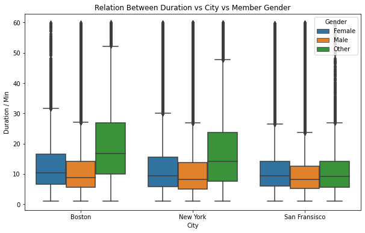

```python
# let's get the relation between duration , city, gender
plt.figure(figsize=[10, 6])
sb.boxplot(data = df_clean_duration, x = 'city',  y = 'duration_min', hue='member_gender')
plt.legend(loc ='upper right', title="Gender")
plt.xlabel("City")
plt.ylabel("Duration / Min")
plt.title('Relation Between Duration vs City vs Member Gender')
plt.show()
```

## Relation Between ( Age, City, User Type)

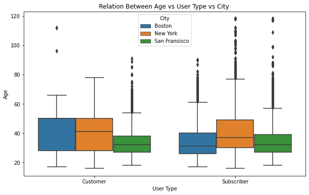

```python
# let's get the relation between age, city, user type
plt.figure(figsize=[10, 6])
sb.boxplot(data = df_clean_duration, x = 'user_type',  y = 'member_age', hue='city')
plt.legend(title="City")
plt.xlabel("User Type")
plt.ylabel("Age")
plt.title('Relation Between Age vs User Type vs City ')
plt.show()
```

## Relation Between (Duration, Age , User Type and Gender)

## Relation Between (Duration, Age , User Type and City)

> From the two relations we can conclude that the jump in the age-duration graph are mainly from customers with gender other in boston city.

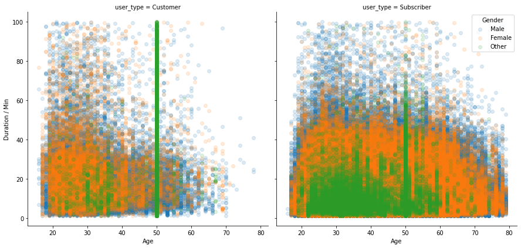

```python
# let's display the relation between duration, age, user type, gender feature
# create faceted heat maps on the user type variable
graph = sb.FacetGrid(data = df_clean_time_age_limit, col = 'user_type', hue='member_gender',hue_order=['Male','Female','Other'], col_wrap = 6, size = 6)
graph.map(plt.scatter, 'member_age', 'duration_min', alpha=0.15)
graph.set_xlabels('Age')
graph.set_ylabels('Duration / Min')
plt.legend(title="Gender")
plt.show()
```

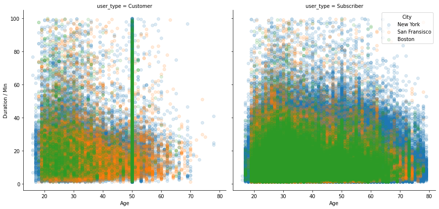

```python
# let's display the relation between duration, age, user type, city feature
# create faceted heat maps on the user type variable
graph = sb.FacetGrid(data = df_clean_time_age_limit, col = 'user_type', hue='city', hue_order=['New York','San Fransisco','Boston'],col_wrap = 6, size = 6)
graph.map(plt.scatter, 'member_age', 'duration_min', alpha=0.15)
graph.set_xlabels('Age')
graph.set_ylabels('Duration / Min')
plt.legend(title="City")
plt.show()
```

## The impact of the project:

> The member health will enhance and they also save money and time.

> The enviroment pollution decrease and the roads will be less crowded due to less cars.

## Future Enhancement:

> Make more activities in week end days to encourage people to ride trips in those days.

> Research on the main reason that leads to the small percentage of females participated.